# Bigdata Analysis (Final Project)

Daeyoon Hwang

Dec 23, 2023

# [주제] 청년인구의 유출입과 지역 인프라의 상관관계 분석

현재 우리나라는 이례적인 저출산 고령화 현상으로 위기에 국면하고 있다. 저출생으로 유소년 인구는 감소하면서 이에 따라 청년 인구 또한 자연스럽게 감소할 것으로 보이며, 기대수명 증가로 인한 노인 인구가 증가함에 고령화 현상은 더욱 심화될 것으로 보인다.

반면, 수도권에 위치한 대학을 우선시하는 경향이 나타나면서 지방의 대학교들이 사라질 위기에 처하고 있다. 또한 대학교 뿐만 아니라 직장 및 사업 등 여러 분야에 걸쳐 이와 같은 현상이 일어나는 것으로 보인다. 저출산 고령화 현상에 더해 청년들이 학업을 이유로, 혹은 직장을 구하기 위하여 지방에서 수도권으로 이동하는 경향이 계속된다면 지방의 고령화 현상은 전국 대비 더욱 악화될 것이며, 수도권과 그 외 지방 도시와의 인구 연령 격차는 더욱 벌어질 것이다.

대한건축학회에 따르면 인구 이동이란 ’경제·문화·지리·인구학적 요인에 의해 한 지역의 인구가 다른 지역으로 이동하는 현상’이라고 한다. 이 연구에서는 연령대별, 특히 청년계층을 중심으로 전출입률을 나타내고, 청년인구 흡인 요인을 설정하여 실제 청년인구 이동과의 연관성을 분석하고자 한다.

# [질문] 분석 질문

본 연구에서는 다음의 질문에 대하여 분석을 진행하고자 한다.

- 1. 우리나라 시도의 인구 유입/유출비의 시간적 변화는 어떻게 나타나는가?
- 2. 우리나라 시도의 청년인구 유입/유출비의 시간적 변화는 어떻게 나타나며, 평균 인구 유입/유출비와의 차이는 어떻게 나타나는가?
- 3. 우리나라 시도의 청년인구 유입/유출비와 인프라의 상관관계는 어떻게 나타나는가?

여기서 인프라는 1)경제인프라 2)교육·문화인프라 3)녹지인프라로 구분되며, 경제인프라의 경우 사업체수, 문화인프라의 경우 대학교, 문화시설과 체육시설, 녹지인프라의 경우 도시공원 데이터를 사용한다. 또한, 모든 데이터는 2020년을 기준으로 하며, 인구 전출입 데이터는 2005년에서 2020년까지의 데이터를 바탕으로 분석한다.

# [데이터] 데이터 출처

위의 분석 질문들에 답하기 위하여 다음의 데이터를 사용하였다.

- KOSIS 국가통계포털
- 연령별 이동자수: https://kosis.kr/statHtml/statHtml.do?orgId=101&tblId=DT_1B26001_A04&vw_cd=MT_ZTITLE&list_id=A34_3&scrId=&seqNo=&lang_mode=ko&obj_var_id=&itm_id=&conn_path=MT_ZTITLE&path=%252FstatisticsList%252FstatisticsListIndex.do
- 대학교 수: https://kosis.kr/statHtml/statHtml.do?orgId=101&tblId=DT_1YL21181&vw_cd=MT_GTITLE01&list_id=104&seqNo=&lang_mode=ko&language=kor&obj_var_id=&itm_id=&conn_path=MT_GTITLE01
- 사업체수: https://kosis.kr/statHtml/statHtml.do?orgId=101&tblId=DT_1K52C01&vw_cd=MT_ZTITLE&list_id=K22_4&scrId=&seqNo=&lang_mode=ko&obj_var_id=&itm_id=&conn_path=MT_ZTITLE&path=%252FstatisticsList%252FstatisticsListIndex.do
- 공원: https://kosis.kr/statHtml/statHtml.do?orgId=460&tblId=TX_315_2009_H1126&vw_cd=MT_ZTITLE&list_id=315_31502_004&seqNo=&lang_mode=ko&language=kor&obj_var_id=&itm_id=&conn_path=MT_ZTITLE
- 도시지역면적: https://kosis.kr/statHtml/statHtml.do?orgId=101&tblId=DT_1YL21291E&vw_cd=MT_GTITLE01&list_id=107&seqNo=&lang_mode=ko&language=kor&obj_var_id=&itm_id=&conn_path=MT_GTITLE01

# [분석1] 인구이동과 도시유형

## [분석1.1] 우리나라 시도의 인구 유입/유출비의 시간적 변화는 어떻게 나타나는가?

강원특별자치도와 경기도, 세종특별자치도, 충청북도, 충청남도의 경우 인구유출에 비해 인구유입이 더 많은 것으로 보이나, 세종특별자치도와 충청남도의 경우 최근 5 ~ 10년간 가파른 하향세를 보인다. 반면, 광주광역시와 대전광역시, 서울특별시의 경우 최근 5년 내 유출인구 대비 유입인구가 증가하는 추세를 보이고 있다.

### 전국

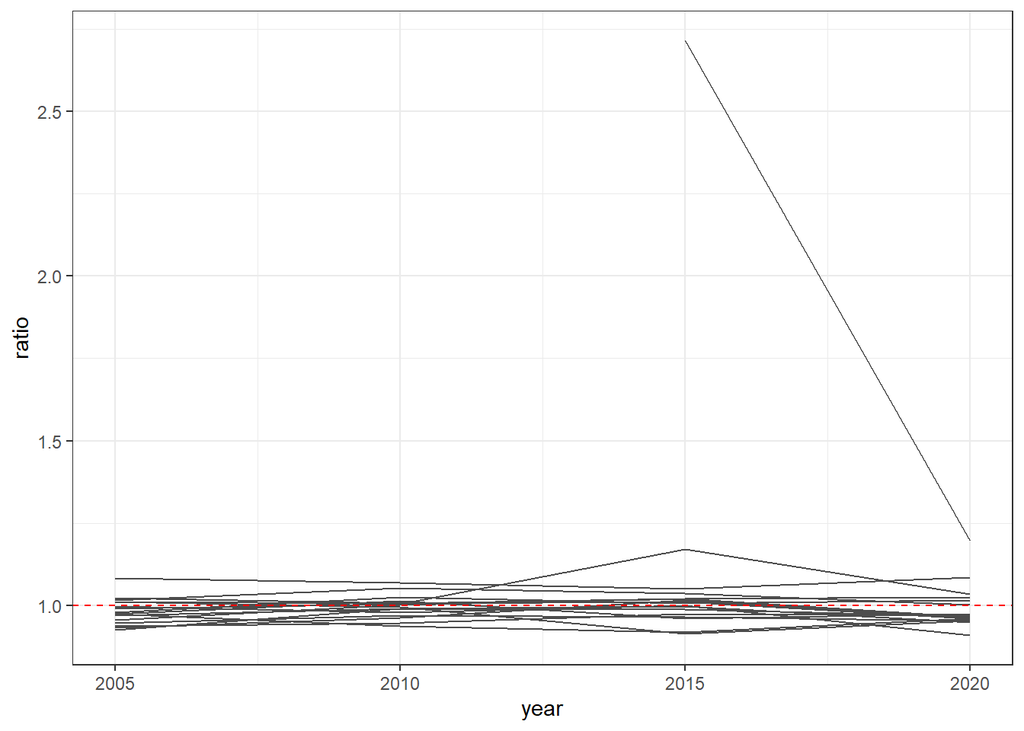

```r
ggplot(move.1.1, aes(x = year, y = ratio, group = name )
) +
  geom_line(linewidth = 0.5, color = "grey30" )+
  geom_hline(yintercept =1, linetype="dashed", color = "red") +
  scale_x_continuous(breaks = seq(2005, 2020, 5)) +
  theme_bw()
```

### 시도별

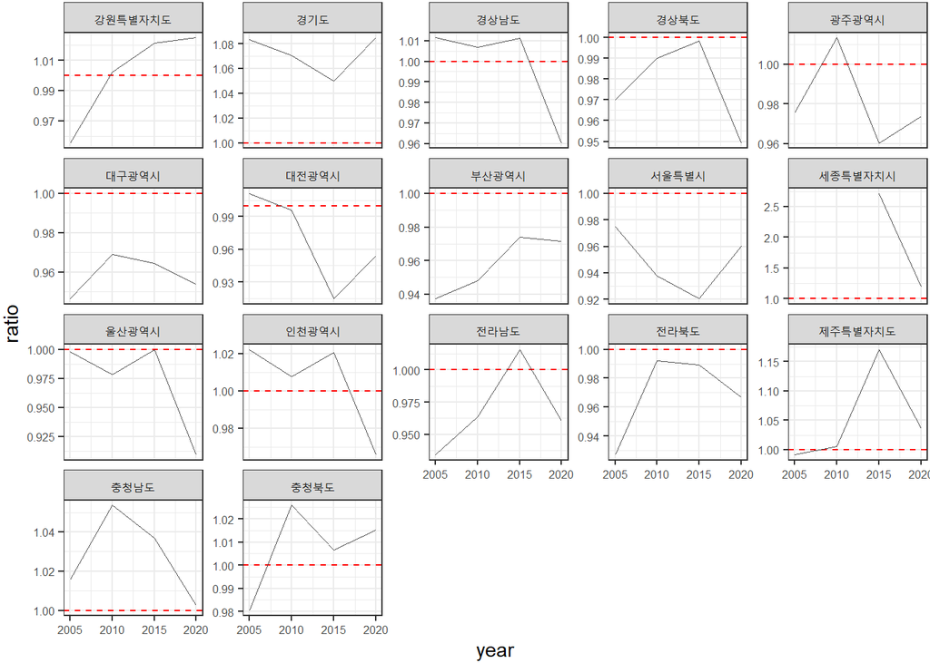

```r
ggplot(move.1.1, aes(x = year, y = ratio, group = name )) +
  geom_hline(yintercept =1, linetype="dashed", color = "red") +
  geom_line(linewidth = 0.3, color = "grey30" )+
  scale_x_continuous(breaks = seq(2005, 2020, 5)) +
  theme_bw() +
  facet_wrap(~ name, ncol = 5, scales = "free_y") +
  theme(
    plot.margin = margin(0.05, 0.05, 0.05, 0.05, "cm"),
    strip.text = element_text(size = 8),
    axis.text.x = element_text(size = 6),
    axis.text.y = element_text(size = 6)
    )
```

## [분석1.2] 우리나라 시도의 청년인구 유입/유출비의 시간적 변화는 어떻게 나타나며, 평균 인구 유입/유출비와의 차이는 어떻게 나타나는가?

청년인구의 경우 총인구와 마찬가지로 경기도 내로 유입되는 현상이 계속되고 있으며, 서울특별시의 경우 최근 5년 내 급격하게 유입되는 경향이 보였다. 반면, 경상남도, 경상북도, 전라남도, 전라북도 등 대부분의 지방에서 계속해서 청년인구가 유출되는 현상이 지속되고 있다.

시도별 총인구 유입/유출비와 청년인구 유입/유출비를 대조하여 바라보았을 때 이러한 경향은 더욱 뚜렷하게 관찰되는데, 서울특별시와 경기도, 인천광역시만이 청년인구의 유입비율이 총인구의 유입비율보다 많은 경향을 보이며, 대부분의 지역에서는 청년인구가 총인구 대비 전출하는 경향이 있음을 관찰할 수 있다. 본 인구 유입/유출비 분석을 통해 지방에서 유출되는 청년인구가 수도권으로 유입됨을 짐작해볼 수 있다.

### 전국

```r
move.1.2 <- move.pop %>%
  mutate(age.1 = str_sub(age, 1, 2)) %>%
  filter(age.1 == 20 |
           age.1 == 25 |
           age.1 == 30 |
           age.1 == 35) %>%
  group_by(name, year) %>%
  summarise(movein = sum(movein),
            moveout = sum(moveout)) %>%
  mutate(ratio_youth = movein/moveout)
```

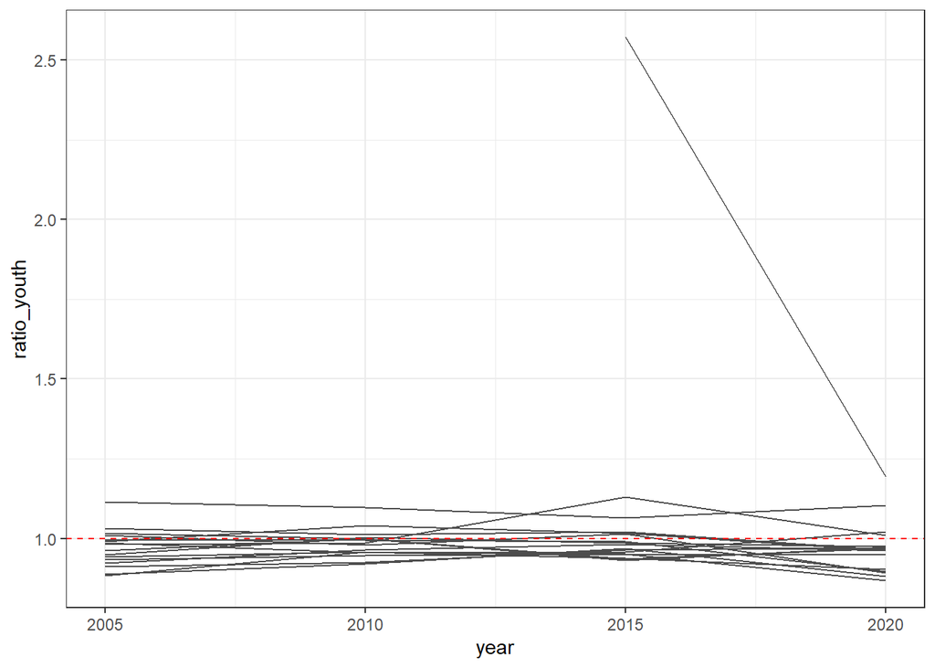

```r
ggplot(move.1.2, aes(x = year, y = ratio_youth, group = name )
) +
  geom_line(linewidth = 0.5, color = "grey30" )+
  geom_hline(yintercept =1, linetype="dashed", color = "red") +
  scale_x_continuous(breaks = seq(2005, 2020, 5)) +
  theme_bw()
```

### 시도별

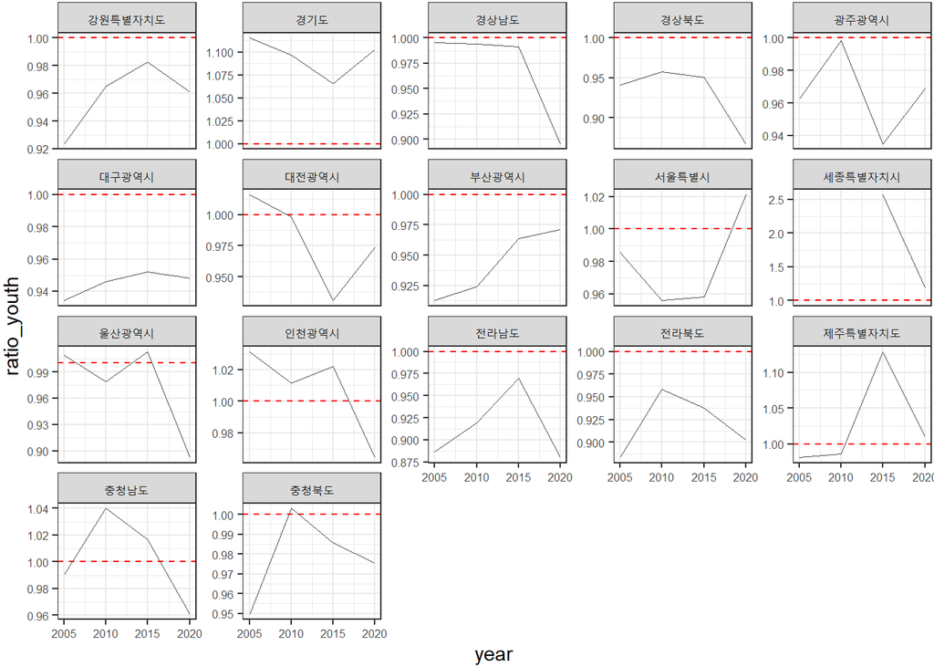

```r
ggplot(move.1.2, aes(x = year, y = ratio_youth, group = name )) +
  geom_hline(yintercept =1, linetype="dashed", color = "red") +
  geom_line(linewidth = 0.3, color = "grey30" )+
  scale_x_continuous(breaks = seq(2005, 2020, 5)) +
  theme_bw() +
  facet_wrap(~ name, ncol = 5, scales = "free_y") +
  theme(
    plot.margin = margin(0.05, 0.05, 0.05, 0.05, "cm"),
    strip.text = element_text(size = 8),
    axis.text.x = element_text(size = 6),
    axis.text.y = element_text(size = 6))
```

### 시도별 총인구 유입/유출비와 청년인구 유입/유출비의 비교

```r
move.1.1 <- move.1.1 %>%
  mutate(pop_move = 'all')

move.1.2 <- move.1.2 %>%
  select(name, year, ratio_youth) %>%
  mutate(ratio = ratio_youth) %>%
  select(-ratio_youth)

move.1.2 <- move.1.2 %>%
  mutate(pop_move = 'youth')

move.1.2.1 <- bind_rows(move.1.1, move.1.2) %>%
  mutate(전출입비 = pop_move) %>%
  select(-pop_move)
```

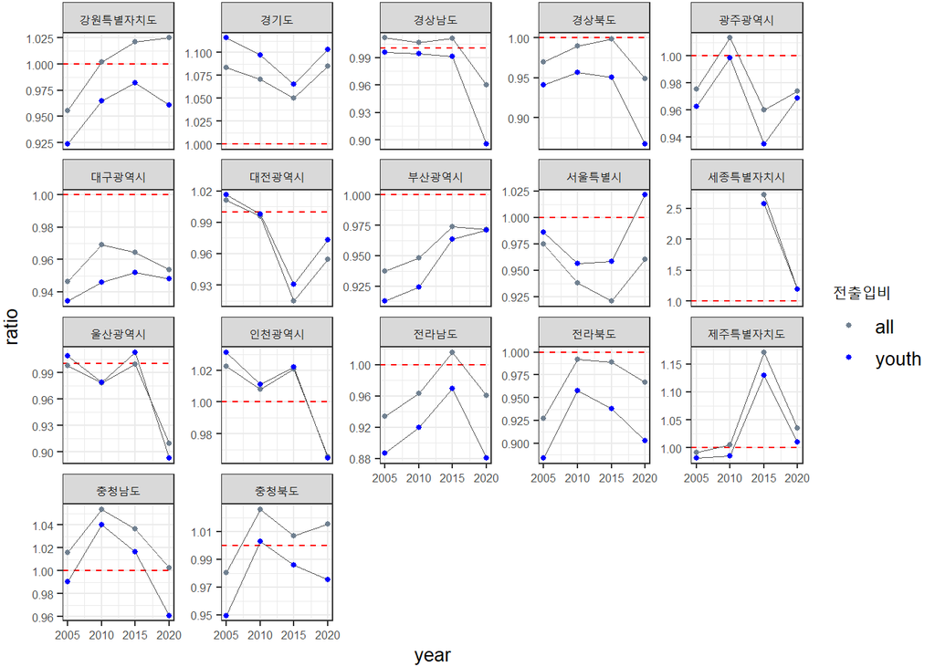

```r
ggplot(move.1.2.1, aes(x = year, y = ratio, colour = 전출입비 , fill = 전출입비)) +
  geom_hline(yintercept =1, linetype="dashed", color = "red") +
  geom_line(linewidth = 0.3, color = "grey30" )+
  scale_x_continuous(breaks = seq(2005, 2020, 5)) +
  theme_bw() +
  scale_color_manual(values = c("all" = "slategrey", "youth" = "blue")) +
  scale_fill_manual(values = c("all" = "slategrey", "youth" = "blue")) +
  geom_point(size = 1, shape = 21)+ ylab("ratio") +
  theme(
    axis.title = element_text(size = 10),
    legend.text = element_text(size = 10)) +
  facet_wrap(~ name, ncol = 5, scales = "free_y") +
    theme(
    plot.margin = margin(0.05, 0.05, 0.05, 0.05, "cm"),
    strip.text = element_text(size = 8),
    axis.text.x = element_text(size = 6),
    axis.text.y = element_text(size = 6))
```

## [분석1.3] 청년인구의 유입/유출비에 따른 도시 유형의 공간분포

각 시도별로 2020년 현재 청년인구 유입/유출비와 2015년에서 2020년까지 최근 5년간 추세를 가지고 네 가지의 도시변화유형으로 구분하였다. 먼저 현재 유입/유출비가 1.0 이상이고 최근 5년간 증가하는 추세인 경우 지속유입지역, 유입/유출비가 1.0 이상이지만 최근 5년간 감소하는 추세인 경우 최근유출지역, 유입/유출비가 1.0 미만이지만 최근 5년간 증가하는 추세인 경우 최근반등지역, 그리고 마지막으로 유입/유출비가 1.0 미만이면서 최근 5년간 감소하는 추세인 경우 지속유출지역으로 분류하였다. 분석 결과, 지속유입지역은 서울특별시와 경기도 뿐으로 수도권이 청년 유입 경향이 강한 것으로 보이며, 강원특별자치도를 비롯하여 제주특별자치도를 제외한 모든 도 단위의 지역이 지속유출지역인 것으로 나타났다.

### 전국

```r
sido <- st_read("C:/Users/USER/Documents/Rstudio/ctprvn_20230729/ctprvn.shp", options = 'ENCODING=cp949') %>%
  st_set_crs(5179) %>% st_transform(4326) %>%
  mutate(name = CTP_KOR_NM) %>%
  select(-CTP_KOR_NM, -CTP_ENG_NM)
```

```
## options:        ENCODING=cp949
```

```r
capital_region <- st_read("C:/Users/USER/Documents/Rstudio/finalproject/수도권경계/수도권_병합.shp", options = 'ENCODING=cp949') %>%
  st_set_crs(5179) %>% st_transform(4326) %>%
  mutate(name = '수도권')
```

```
## options:        ENCODING=cp949
```

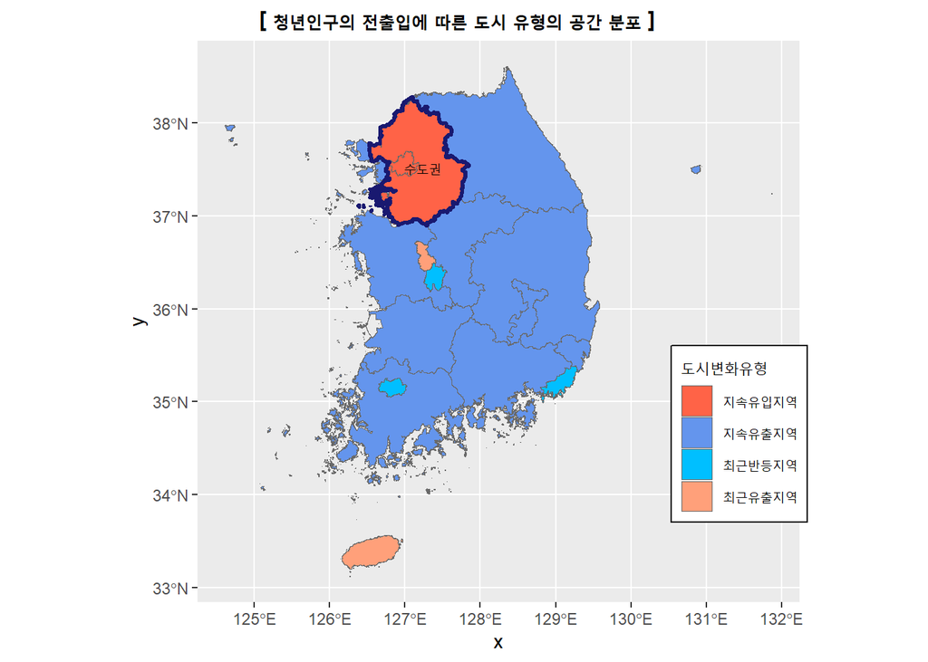

```r
move.1.3 <- read.csv("C:/Users/USER/Documents/Rstudio/finalproject/시군구_연령_5세_별_이동자수1.csv", fileEncoding = 'CP949') %>%
  select(-movein_05, -moveout_05, -net_05, -movein_10, -moveout_10, -net_10) %>%
  mutate(age.1 = str_sub(age, 1, 2)) %>%
  filter(age.1 == 20 |
           age.1 == 25 |
           age.1 == 30 |
           age.1 == 35) %>%
  group_by(name) %>%
  summarise(
    movein_15 = sum(movein_15),
    moveout_15 = sum(moveout_15),
    movein_20 = sum(movein_20),
    moveout_20 = sum(moveout_20)
    )

move.1.3 <- move.1.3 %>%
  mutate(
    y.ratio_15 = movein_15/moveout_15,
    y.ratio_20 = movein_20/moveout_20,
    rebound = ifelse(y.ratio_20 - y.ratio_15 > 0, 'Y', 'N'),
    type = ifelse(y.ratio_20 > 1 & rebound == 'Y', '지속유입지역',
                  ifelse(y.ratio_20 > 1 & rebound == 'N', '최근유출지역',
                         ifelse(y.ratio_20 < 1 & rebound == 'Y', '최근반등지역', '지속유출지역')))
    )


sido.join <- sido %>%
  left_join(move.1.3, by = c("name")) %>%
  mutate(code = CTPRVN_CD) %>%
  select(code, everything(), -CTPRVN_CD)

ggplot()  +
  geom_sf(data = sido.join, aes(fill = type), col = 'dimgray', linewidth = 0.3) +
  scale_fill_manual(name = "도시변화유형",
                    values = c("지속유입지역" = "tomato",
                               "최근유출지역" = "lightsalmon",
                               "최근반등지역" = "deepskyblue",
                               "지속유출지역" = "cornflowerblue")) +
  geom_sf(data = capital_region, fill = NA, col = "midnightblue", linewidth = 1.0) +
  geom_sf_text(data = capital_region, aes(label = name), vjust = 1.0, size = 3) +
  theme(
    legend.position = c(0.9, 0.3),
    legend.background = element_rect(fill = "transparent"),
    legend.box.background = element_rect(color = "black"),
    plot.title = element_text(size = 12, face = "bold", hjust = 0.3)) +
  ggtitle("[ 청년인구의 전출입에 따른 도시 유형의 공간 분포 ]")
```

### 수도권

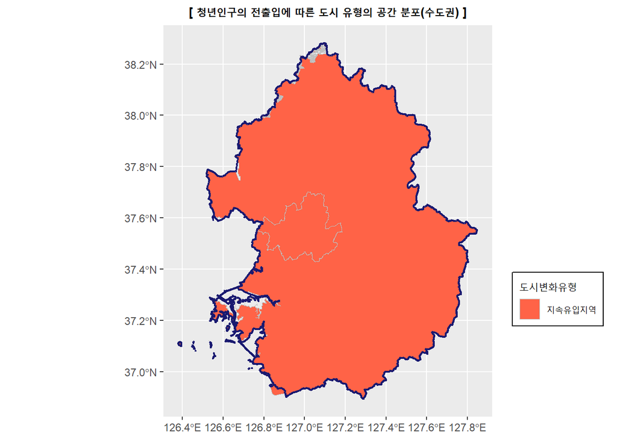

```r
metro <- sido.join %>%
  filter(code == 11 | code == 41)

ggplot()  +
    geom_sf(data = metro, aes(fill = type), col = 'grey75', linewidth = 0.3) +
    scale_fill_manual(name = "도시변화유형",
                     values = c("지속유입지역" = "tomato",
                               "최근유출지역" = "lightsalmon",
                               "최근반등지역" = "deepskyblue",
                               "지속유출지역" = "cornflowerblue")) +
    geom_sf(data = capital_region, fill = NA, col = "midnightblue", linewidth = 0.8) +
    theme(
      legend.position = c(1.2, 0.3),
      legend.background = element_rect(fill = "transparent"),
      legend.box.background = element_rect(color = "black"),
      plot.title = element_text(size = 10, face = "bold", hjust = 0.5)) +
  ggtitle("[ 청년인구의 전출입에 따른 도시 유형의 공간 분포(수도권) ]")
```

# [분석2] 청년인구의 유입/유출비와 주요시설 간 상관관계 분석

## [분석2.1] 인프라 조성 환경에 따른 공간 분포도

청년인구를 유입하는 흡인요소로 사업체수와 대학교, 문화시설, 체육시설, 공원을 선정하였으며, 대학교를 제외한 나머지 시설들에 대해 녹지지역을 제외한 도시면적 당 시설 개수로 분석을 수행하였다. 공간 분포도를 보면 알 수 있듯이, 대부분의 인프라가 수도권을 중심으로 집중되어 있음을 알 수 있으며, 특히 서울특별시와 타 지역 간의 격차가 매우 큰 것으로 보인다.

### 사업체수

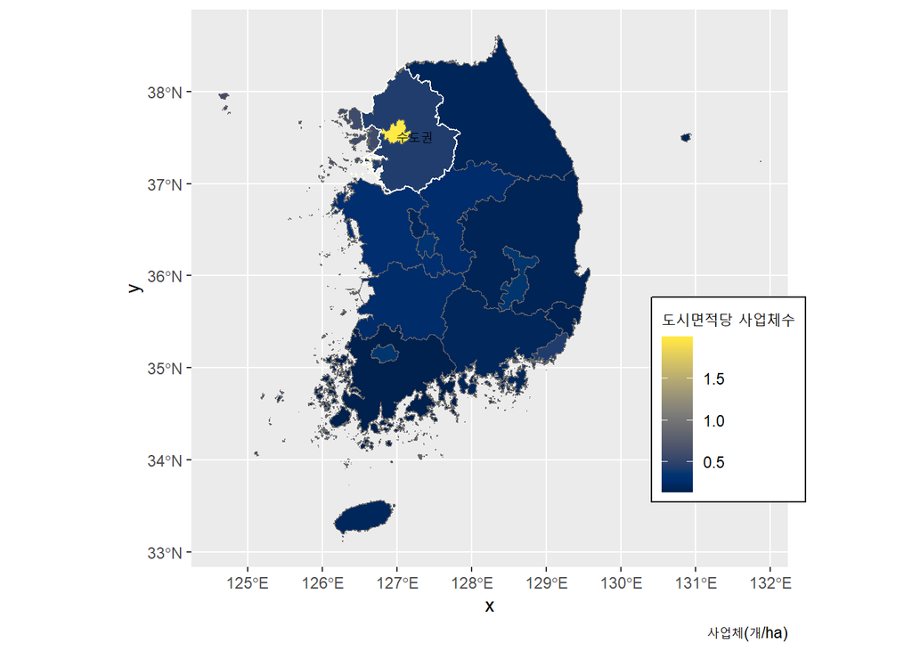

```r
library(viridis)

esta <- read.csv("C:/Users/USER/Documents/Rstudio/finalproject/시도·산업·사업체구분별_사업체수__종사자수.csv", fileEncoding = 'CP949')

area <- read.csv("C:/Users/USER/Documents/Rstudio/finalproject/도시지역면적_시도_시_군_구.csv", fileEncoding = 'CP949')

esta.by.area <- esta %>%
  left_join(area, by = c('name')) %>%
  mutate(
    area_ha = area/1000,
    esta_area_ha = 전체.산업/area_ha
    )

sido.join <- sido.join %>%
  left_join(esta.by.area, by = c('name'))

ggplot() +
  geom_sf(data = sido.join, aes(fill = esta_area_ha), col = 'dimgray', linewidth = 0.3) +
  scale_fill_viridis(name = '도시면적당 사업체수', option = 'cividis', discrete = FALSE) +
  geom_sf_text(data = capital_region, aes(label = name), vjust = 1.0, size = 3) +
  geom_sf(data = capital_region, fill = NA, col = "ivory", linewidth = 0.5) +
  labs(caption = '사업체(개/ha)') +
  theme(
    legend.position = c(0.9, 0.3),
    legend.background = element_rect(fill = "transparent"),
    legend.box.background = element_rect(color = "black"),
    plot.title = element_text(size = 12, face = "bold", hjust = 0.3))
```

### 대학교 수

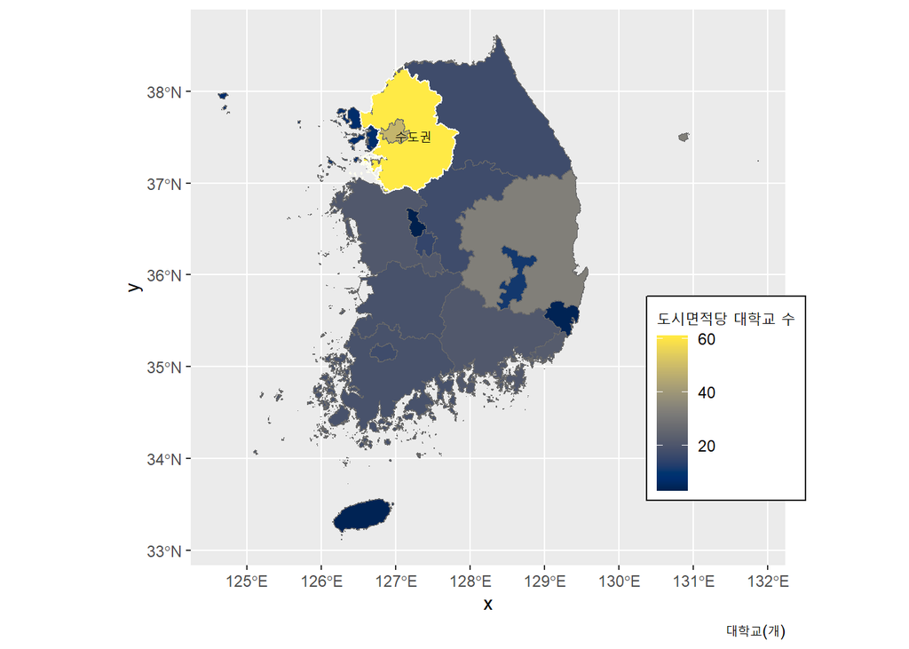

```r
univ <- read.csv("C:/Users/USER/Documents/Rstudio/finalproject/대학교_수_시도_시_군_구.csv", fileEncoding = 'CP949')

sido.join <- sido.join %>%
  left_join(univ, by = c('name'))

ggplot() +
  geom_sf(data = sido.join, aes(fill = univ), col = 'dimgray', linewidth = 0.3) +
  scale_fill_viridis(name = '도시면적당 대학교 수', option = 'cividis', discrete = FALSE) +
  geom_sf_text(data = capital_region, aes(label = name), vjust = 1.0, size = 3) +
  geom_sf(data = capital_region, fill = NA, col = "ivory", linewidth = 0.5) +
  labs(caption = '대학교(개)') +
  theme(
    legend.position = c(0.9, 0.3),
    legend.background = element_rect(fill = "transparent"),
    legend.box.background = element_rect(color = "black"),
    plot.title = element_text(size = 12, face = "bold", hjust = 0.3))
```

### 문화시설 수

서을특별시가 1km²당 가장 많은 16.7개의 문화시설을 보유하고 있으며, 이 또한 두번째로 높은 수치인 인천광역시의 2.6개와 14.1개의 매우 큰 격차를 보인다. 0.6개로 가장 적은 문화시설을 보유하고 있는 경상북도를 포함하여, 전라남도, 경상남도, 울산광역시의 경우 1km²당 1.0개의 문화시설도 보유하지 못한 것으로 분석된다.

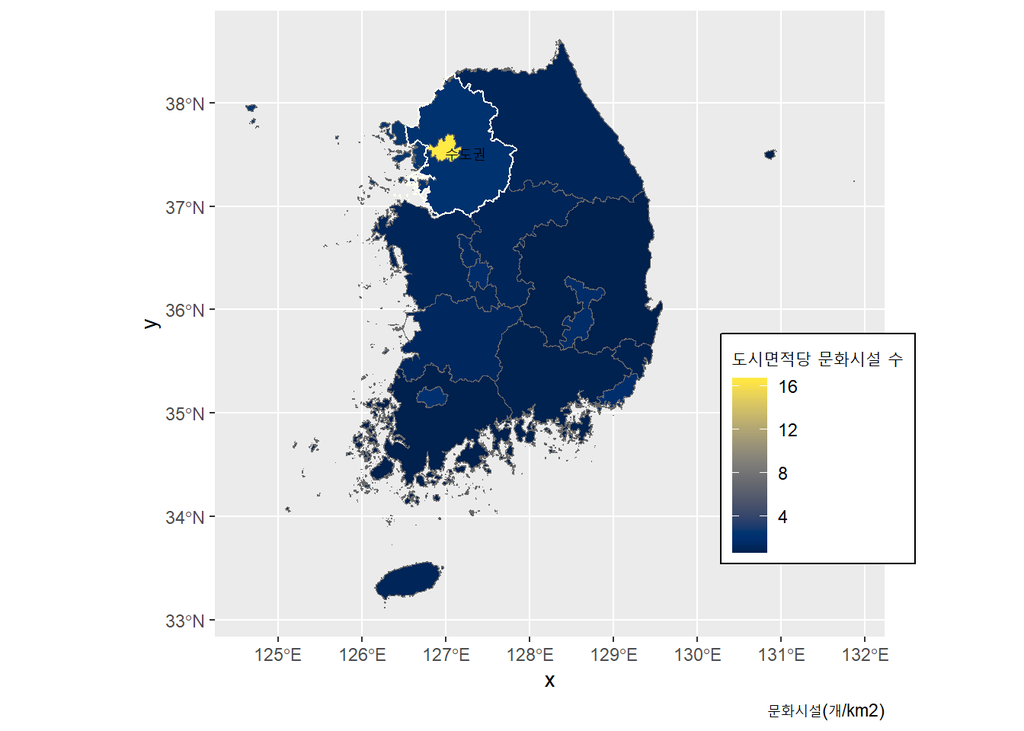

```r
sido.join <- sido.join %>%
  mutate(area_km2 = area/1000000,
         cul_area_km2 = 창작.예술.및.여가관련.서비스업/area_km2)

ggplot() +
  geom_sf(data = sido.join, aes(fill = cul_area_km2), col = 'dimgray', linewidth = 0.3) +
  scale_fill_viridis(name = '도시면적당 문화시설 수', option = 'cividis', discrete = FALSE) +
  geom_sf_text(data = capital_region, aes(label = name), vjust = 1.0, size = 3) +
  geom_sf(data = capital_region, fill = NA, col = "ivory", linewidth = 0.5) +
  labs(caption = '문화시설(개/km2)') +
  theme(
    legend.position = c(0.9, 0.3),
    legend.background = element_rect(fill = "transparent"),
    legend.box.background = element_rect(color = "black"),
    plot.title = element_text(size = 12, face = "bold", hjust = 0.3))
```

### 체육시설 수

서울특별시가 1km²당 14.3개로 가장 많은 체육시설을 보유하고 있으며, 인천광역시가 4.5개로 그 뒤를 잇는다.

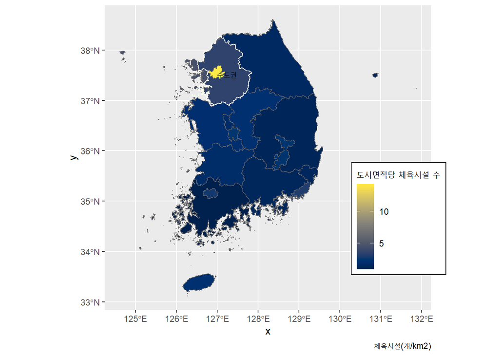

```r
sido.join <- sido.join %>%
  mutate(phy_area_km2 = 스포츠.서비스업/area_km2)

ggplot() +
  geom_sf(data = sido.join, aes(fill = phy_area_km2), col = 'dimgray', linewidth = 0.3) +
  scale_fill_viridis(name = '도시면적당 체육시설 수', option = 'cividis', discrete = FALSE) +
  geom_sf_text(data = capital_region, aes(label = name), vjust = 1.0, size = 3) +
  geom_sf(data = capital_region, fill = NA, col = "ivory", linewidth = 0.5) +
  labs(caption = '체육시설(개/km2)') +
  theme(
    legend.position = c(0.9, 0.3),
    legend.background = element_rect(fill = "transparent"),
    legend.box.background = element_rect(color = "black"),
    plot.title = element_text(size = 12, face = "bold", hjust = 0.3))
```

### 공원 수

서울특별시가 1km²당 3.6개로 가장 많은 공원을 보유하고 있으며, 세종특별자치시가 2.4개로 두번 째로 많은 공원을 보유하고 있다. 그 다음으로 인천광역시와 경기도, 충청북도 순으로 많은데, 기후변화에 대응하기 위한 노력과 주민들의 삶의 질 향상 등을 위해 신도시 조성 시 녹지율을 증가하면서 그 영향이 있을 것으로 보인다. 공원의 경우 다른 시설들에 비해 상대적으로 격차가 덜 한 것으로 관찰된다.

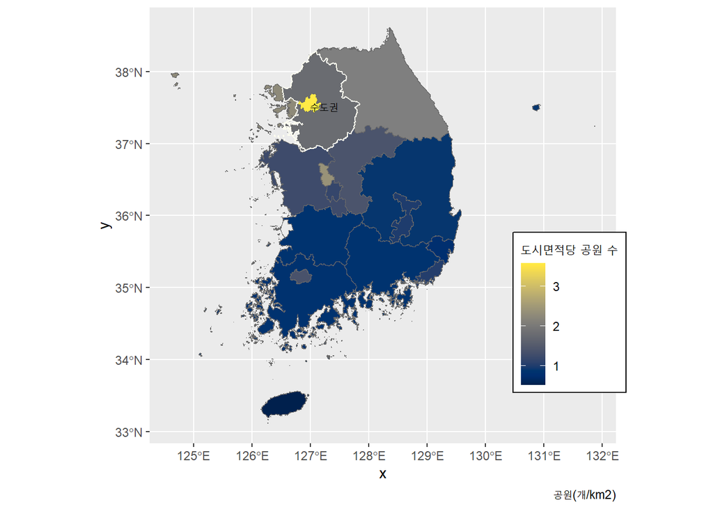

```r
park <- read.csv("C:/Users/USER/Documents/Rstudio/finalproject/공원.csv", fileEncoding = 'CP949')

sido.join <- sido.join %>%
  left_join(park, by = c('name')) %>%
  mutate(park_area_km2 = 공원수/area_km2)

ggplot() +
  geom_sf(data = sido.join, aes(fill = park_area_km2), col = 'dimgray', linewidth = 0.3) +
  scale_fill_viridis(name = '도시면적당 공원 수', option = 'cividis', discrete = FALSE) +
  geom_sf_text(data = capital_region, aes(label = name), vjust = 1.0, size = 3) +
  geom_sf(data = capital_region, fill = NA, col = "ivory", linewidth = 0.5) +
  labs(caption = '공원(개/km2)') +
  theme(
    legend.position = c(0.9, 0.3),
    legend.background = element_rect(fill = "transparent"),
    legend.box.background = element_rect(color = "black"),
    plot.title = element_text(size = 12, face = "bold", hjust = 0.3))
```

## [분석2.2] 지역별 인프라 조성 현황

### 사업체수

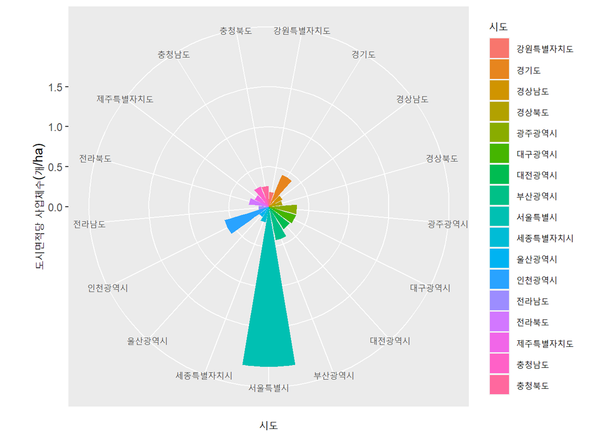

```r
ggplot(data = sido.join) +
  geom_bar(mapping = aes(x = name, y = esta_area_ha, fill = name), stat = "identity")+ coord_polar() +
  labs(x = "시도",
       y = "도시면적당 사업체수(개/ha)",
       fill = '시도'
       )
```

### 대학교 수

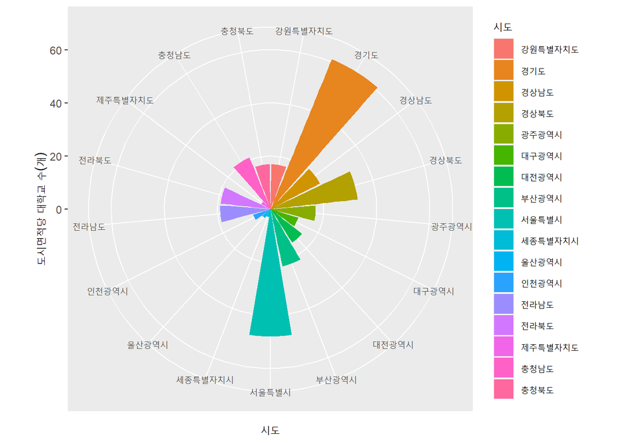

```r
ggplot(data = sido.join) +
  geom_bar(mapping = aes(x = name, y = univ, fill = name), stat = "identity")+ coord_polar() +
  labs(x = "시도",
       y = "도시면적당 대학교 수(개)",
       fill = '시도'
       )
```

### 문화시설 수

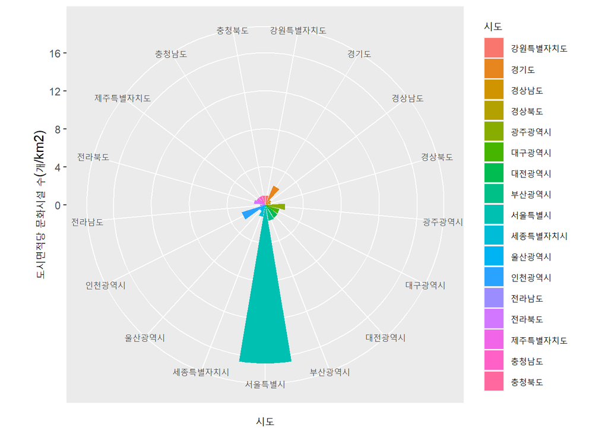

```r
ggplot(data = sido.join) +
  geom_bar(mapping = aes(x = name, y = cul_area_km2, fill = name), stat = "identity")+ coord_polar() +
  labs(x = "시도",
       y = "도시면적당 문화시설 수(개/km2)",
       fill = '시도'
       )
```

### 체육시설 수

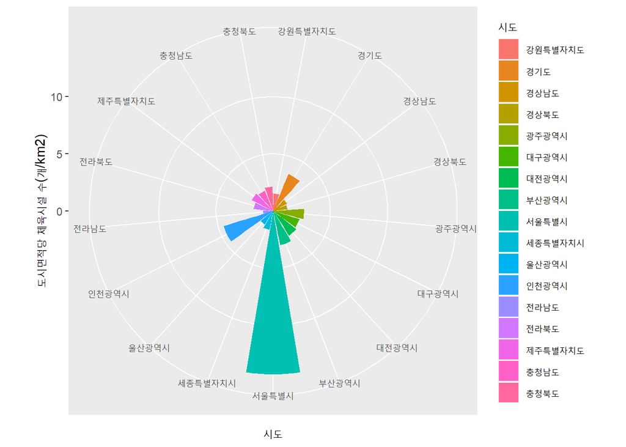

```r
ggplot(data = sido.join) +
  geom_bar(mapping = aes(x = name, y = phy_area_km2, fill = name), stat = "identity")+ coord_polar() +
  labs(x = "시도",
       y = "도시면적당 체육시설 수(개/km2)",
       fill = '시도'
       )
```

### 공원 수

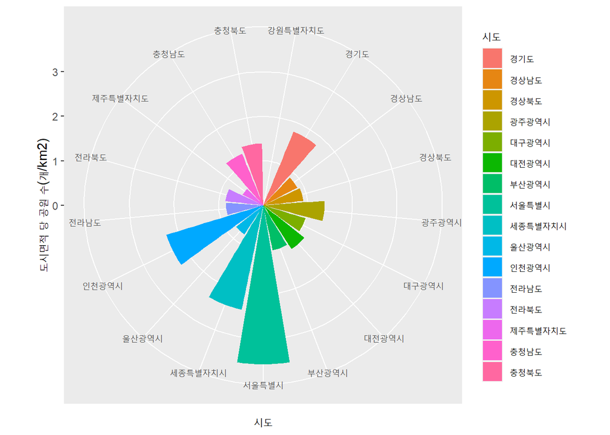

```r
ggplot(data = sido.join) +
  geom_bar(mapping = aes(x = name, y = park_area_km2, fill = name), stat = "identity")+ coord_polar() +
  labs(x = "시도",
       y = "도시면적 당 공원 수(개/km2)",
       fill = '시도'
       )
```

## [분석2.3] 청년인구의 유입/유출비와 인프라 조성 현황 간 상관관계

대부분의 차트에서 우향 - 우상향의 그래프를 보이고 있다. 그래프가 우상향하지 못하고 계속해서 우향하거나 굴절되는 것을 관찰할 수 있는데, 이는 서울특별시가 타 지역과 비교해 보았을 때, 청년인구 유입/유출비 대비 많은 인프라를 보유하고 있어 이러한 경향이 보이는 것으로 판단된다.

### 사업체수

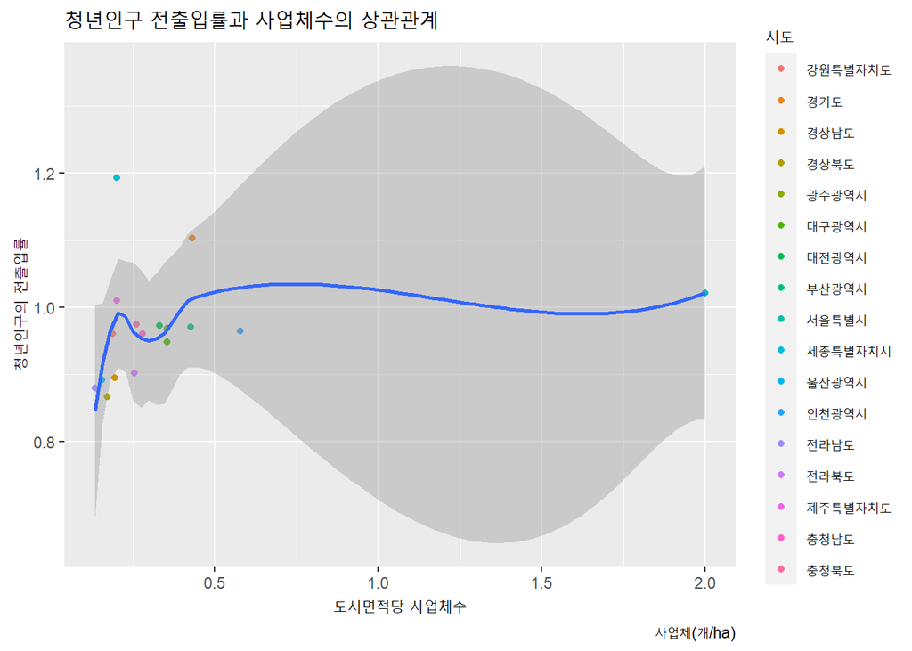

```r
ggplot(sido.join) +
  geom_point(aes(x = esta_area_ha, y = y.ratio_20, color = name)) +
  labs(x = "도시면적당 사업체수",
       y = "청년인구의 전출입률",
       color = '시도',
       title = "청년인구 전출입률과 사업체수의 상관관계",
       caption = "사업체(개/ha)") +
  geom_smooth(mapping = aes(x = esta_area_ha, y = y.ratio_20))
```

### 대학교 수

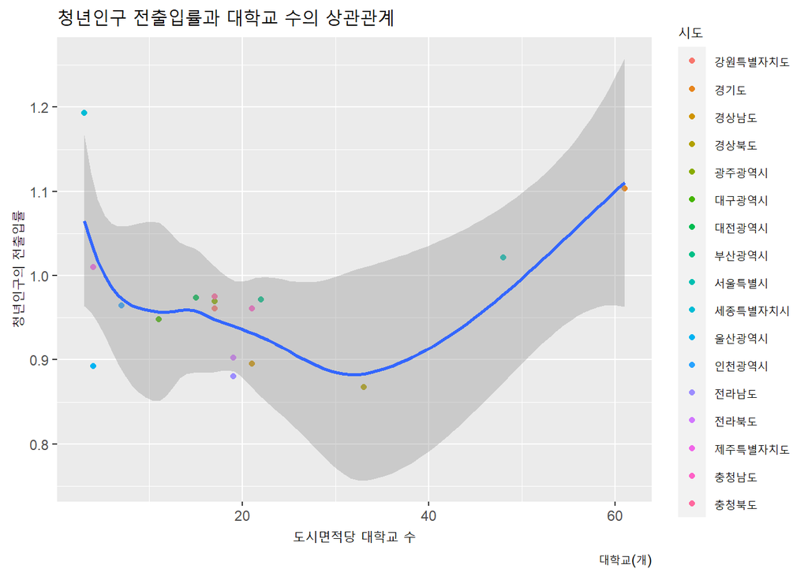

```r
ggplot(sido.join) +
  geom_point(aes(x = univ, y = y.ratio_20, color = name)) +
  labs(x = "도시면적당 대학교 수",
       y = "청년인구의 전출입률",
       color = '시도',
       title = "청년인구 전출입률과 대학교 수의 상관관계",
       caption = "대학교(개)") +
  geom_smooth(mapping = aes(x = univ, y = y.ratio_20))
```

### 문화시설 수

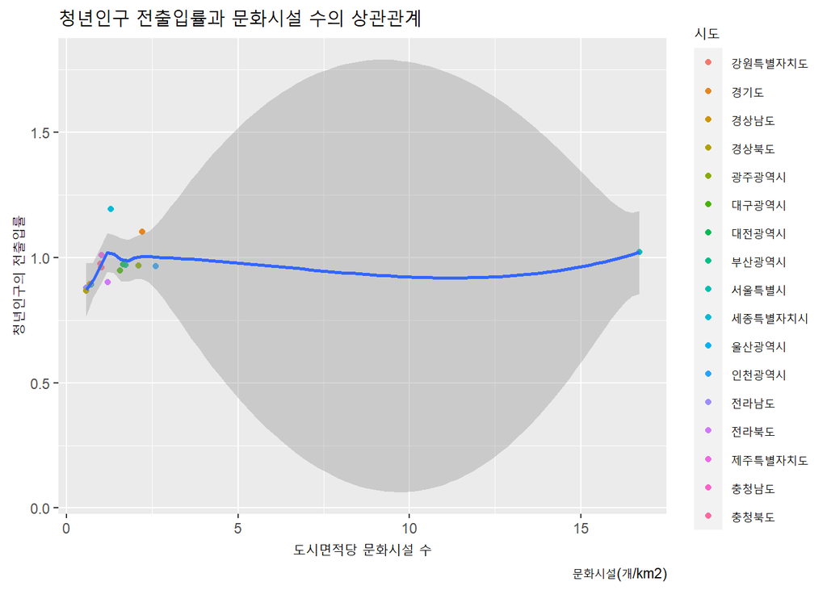

```r
ggplot(sido.join) +
  geom_point(aes(x = cul_area_km2, y = y.ratio_20, color = name)) +
  labs(x = "도시면적당 문화시설 수",
       y = "청년인구의 전출입률",
       color = '시도',
       title = "청년인구 전출입률과 문화시설 수의 상관관계",
       caption = "문화시설(개/km2)") +
  geom_smooth(mapping = aes(x = cul_area_km2, y = y.ratio_20))
```

### 체육시설 수

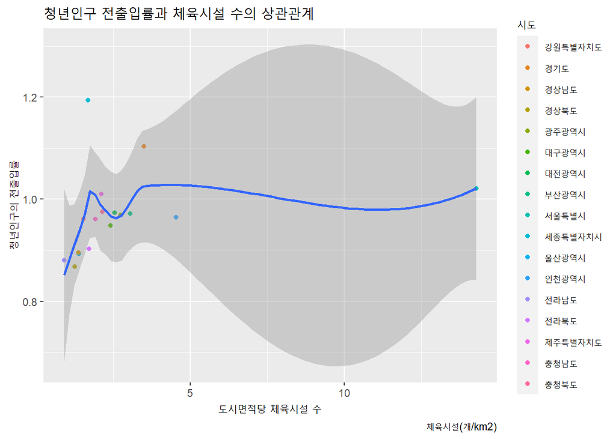

```r
ggplot(sido.join) +
  geom_point(aes(x = phy_area_km2, y = y.ratio_20, color = name)) +
  labs(x = "도시면적당 체육시설 수",
       y = "청년인구의 전출입률",
       color = '시도',
       title = "청년인구 전출입률과 체육시설 수의 상관관계",
       caption = "체육시설(개/km2)") +
  geom_smooth(mapping = aes(x = phy_area_km2, y = y.ratio_20))
```

### 공원 수

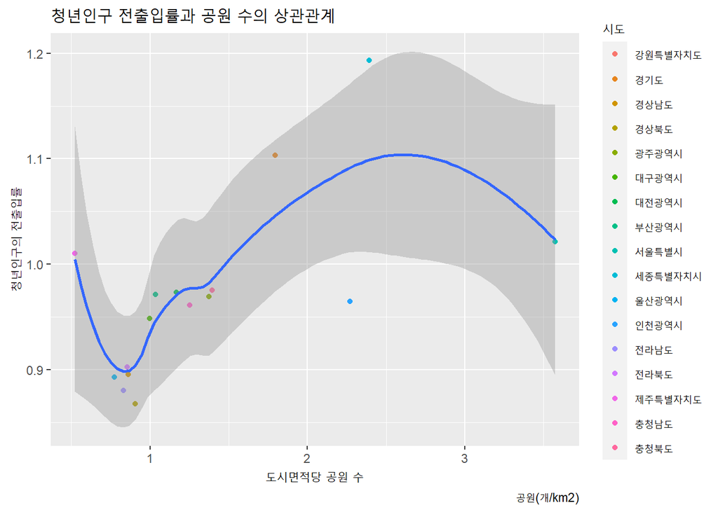

```r
ggplot(sido.join) +
  geom_point(aes(x = park_area_km2, y = y.ratio_20, color = name)) +
  labs(x = "도시면적당 공원 수",
       y = "청년인구의 전출입률",
       color = '시도',
       title = "청년인구 전출입률과 공원 수의 상관관계",
       caption = "공원(개/km2)") +
  geom_smooth(mapping = aes(x = park_area_km2, y = y.ratio_20))
```

# [결론] 결론

본 연구에서 아쉬웠던 점으로는 구 단위의 분석이 이루어지지 못한 점과 회귀 분석을 수행하지 못한 점, 그리고 흡인 요소 선정에 있어 객관성이 결여된다는 점 등을 들 수 있다.